# Inzicht krijgen in de FIFA-spelers

Eindopdracht van Sander van der Most (2021)

## 2. Dataset ontdekken

We tonen hieronder de eerste 5 regels van de dataset om een beter beeld te krijgen van de data.

```python
df.head()
```

|  | id | name | full_name | birth_date | age | height_cm | weight_kgs | positions | nationality | overall_rating | ... | lwb | ldm | cdm | rdm | rwb | lb | lcb | cb | rcb | rb |
| --- | --- | --- | --- | --- | --- | --- | --- | --- | --- | --- | --- | --- | --- | --- | --- | --- | --- | --- | --- | --- | --- |
| 0 | 158023 | L. Messi | Lionel Andrés Messi Cuccittini | 1987-06-24 | 31 | 170.18 | 72.1 | CF,RW,ST | Argentina | 94 | ... | 64+2 | 61+2 | 61+2 | 61+2 | 64+2 | 59+2 | 48+2 | 48+2 | 48+2 | 59+2 |
| 1 | 190460 | C. Eriksen | Christian Dannemann Eriksen | 1992-02-14 | 27 | 154.94 | 76.2 | CAM,RM,CM | Denmark | 88 | ... | 71+3 | 71+3 | 71+3 | 71+3 | 71+3 | 66+3 | 57+3 | 57+3 | 57+3 | 66+3 |
| 2 | 195864 | P. Pogba | Paul Pogba | 1993-03-15 | 25 | 190.50 | 83.9 | CM,CAM | France | 88 | ... | 76+3 | 77+3 | 77+3 | 77+3 | 76+3 | 74+3 | 72+3 | 72+3 | 72+3 | 74+3 |
| 3 | 198219 | L. Insigne | Lorenzo Insigne | 1991-06-04 | 27 | 162.56 | 59.0 | LW,ST | Italy | 88 | ... | 63+3 | 58+3 | 58+3 | 58+3 | 63+3 | 58+3 | 44+3 | 44+3 | 44+3 | 58+3 |
| 4 | 201024 | K. Koulibaly | Kalidou Koulibaly | 1991-06-20 | 27 | 187.96 | 88.9 | CB | Senegal | 88 | ... | 73+3 | 77+3 | 77+3 | 77+3 | 73+3 | 76+3 | 85+3 | 85+3 | 85+3 | 76+3 |

5 rows × 92 columns

### 2.1 Interpretatie van de data

We kunnen hierin zien dat het gaat om een lijst van spelers waarvan er in totaal 92 kolommen aan data is bijgehouden. Sommige data is positiespecifiek of bestaat niet, aangezien het hier dan bijvoorbeeld niet gaat om een speler die uitkomt voor zijn nationale elftal.

Verder is te zien dat een speler op verschillende posities kan spelen. Aangezien ik per positie een dataframe wil maken zullen er meerdere kolommen gerealiseerd worden uit de kolom positions. Dit zal gedaan worden onder "Schoonmaken / manipuleren van data".

## 3. Schoonmaken / manipuleren van data

Om een goede onderverdeling per positie te maken wordt de positieskolom eerst gesplitst in 4 kolommen (dit is het maximale aantal posities wat een enkele speler bezit in de dataset).

Vervolgens worden de dataframes gemaakt en worden de spelers afhankelijk van hun positie in het daarvoor bestemde dataframe gestopt. Het kan in dit geval zijn dat een speler in meerdere dataframes terecht komt. Dit is een bewuste keuze. Als iemand zowel op het middenveld als in de verdediging speelt, ben je zowel verdediger, als middenvelder.

```python
df[['position1', 'position2', 'position3', 'position4']] = df['positions'].str.split(',', expand=True)

keepers = df[df['positions'] == "GK"]

backFilter = ["CB","LB","RB","RWB","LWB"]
backs = df[df['position1'].isin(backFilter) |
             df['position2'].isin(backFilter) |
             df['position3'].isin(backFilter) |
             df['position4'].isin(backFilter)]

midfieldFilter = ["CAM","CM","RM","LM","CDM"]
midfielders = df[df['position1'].isin(midfieldFilter) |
              df['position2'].isin(midfieldFilter) |
              df['position3'].isin(midfieldFilter) |
              df['position4'].isin(midfieldFilter)]

strikerFilter = ["ST","CF","RW","LW"]
strikers = df[df['position1'].isin(strikerFilter) |
            df['position2'].isin(strikerFilter) |
            df['position3'].isin(strikerFilter) |
            df['position4'].isin(strikerFilter)]

print(len(keepers), "Keepers")
print(len(backs), "Backs")
print(len(midfielders), "Midfielders")
print(len(strikers), "Strikers")
```

```
2065 Keepers
6571 Backs
8496 Midfielders
4333 Strikers
```

## 4. Onderzoeksvragen.

Nu de data is opgeschoont en gevormd kunnen we de vragen gaan stellen, hypotheses opstellen en conclusies trekken.

### 4.1 Leeftijdsverdeling

Binnen in de sport (en het leven) is er een optimum leeftijd. Sporters groeien, trainen, worden sterker en krijgen meer ervaring. Uiteindelijk zijn ze niet sterk, of snel genoeg meer en worden ze vervangen voor nieuwe spelers. Ik ben benieuwd wanneer doorgaans de spelers een punt achter hun carriere zetten en of er andere factoren meespelen bij deze beslissingen.

#### 4.1.1 Hoe is de leeftijdsverdeling binnen de fifa-spelers?

Om dit te onderzoeken bekijken we eerst de "samenvatting" van de leeftijdskolom. Hier kunnen we een beter beeld krijgen welke data interessant is om nader te bekijken en op welke manier we deze informatie efficient kunnen weergeven.

```python
df['age'].describe()
```

```
count    17954.000000
mean        25.565445
std          4.705708
min         17.000000
25%         22.000000
50%         25.000000
75%         29.000000
max         46.000000
Name: age, dtype: float64
```

#### 4.1.2 Verschilt deze verdeling per veldpositie?

Om dit te bepalen maken we verschillende histplots om het aantal spelers te bekijken per leeftijdsgroep. Om ook goed te kunnen zien of er in een leeftijdsgroep weinig of geen datapunten zitten, is er gekozen voor een logaritmische schaal.

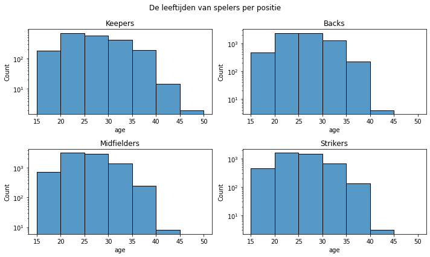

```python
bins = np.linspace(15,50,8)

fig, axs = plt.subplots(2, 2, figsize = (10,6))

fig.suptitle("De leeftijden van spelers per positie")
sns.histplot(x=keepers['age'], bins=bins, label='Keepers', ax= axs[0,0])
axs[0,0].set_title("Keepers")
axs[0,0].set_yscale('log')

sns.histplot(x=backs['age'], bins=bins, label='Backs', ax= axs[0,1])
axs[0,1].set_title("Backs")
axs[0,1].set_yscale('log')

sns.histplot(x=midfielders['age'], bins=bins, label='Midfielders', ax= axs[1,0])
axs[1,0].set_title("Midfielders")
axs[1,0].set_yscale('log')

sns.histplot(x=strikers['age'], bins=bins, label='Strikers', ax= axs[1,1])
axs[1,1].set_title("Strikers")
axs[1,1].set_yscale('log')

plt.tight_layout()
plt.show()
```

#### 4.1.2 Conclusie

Zoals te zien is lijkt de positie alleen uit te maken als het de keeper betreft. De overige grafieken volgen dezelfde curve. Aangezien een keeper minder hoeft te lopen en ervaring een grotere rol speelt, is dit een logische bevinding.

#### 4.1.3 Heeft dit invloed op de overall rating?

Om dit te bepalen maken we verschillende boxplots van de spelers met op de x-as de leeftijd en op de y-as de rating.

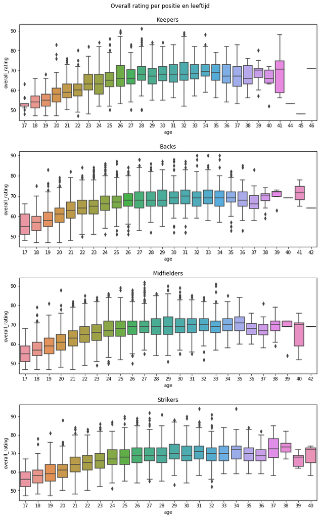

```python
fig, axs = plt.subplots(4, 1, figsize=(10, 16))

fig.suptitle('Overall rating per positie en leeftijd')

axs[0].set_title("Keepers")
sns.boxplot(ax=axs[0], data=keepers, x='age', y='overall_rating')

axs[1].set_title("Backs")
sns.boxplot(ax=axs[1], data=backs, x='age', y='overall_rating')

axs[2].set_title("Midfielders")
sns.boxplot(ax=axs[2], data=midfielders, x='age', y='overall_rating')

axs[3].set_title("Strikers")
sns.boxplot(ax=axs[3], data=strikers, x='age', y='overall_rating')

plt.tight_layout(pad=2)
plt.show()
```

Welke verdeling is er tussen rechts- en linksbenigen?

*Hypothese: Aangezien er meer mensen rechts dan links zijn vermoed ik een groter aandeel rechts te zien.*

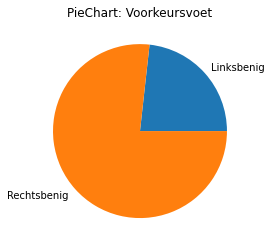

```python
left = df.loc[df['preferred_foot'] == 'Left'].count()[0]
right = df.loc[df['preferred_foot'] == 'Right'].count()[0]

labels = ["Linksbenig", "Rechtsbenig"]
plt.pie([left,right], labels = labels)
plt.title('PieChart: Voorkeursvoet')
plt.show()
```

Conclusie Er zijn inderdaad meer rechts-, dan linkspoten.

### Welk land is het beste in opleiden?

Om dit te bepalen kijken we naar het gemiddelde van de overall_rating van de spelers gegroepeerd op land van herkomst en land van club waar ze nu spelen.

Om dit te realiseren hebben we een extra kolom nodig met landen waarin een club zich bevindt. Aangezien ik hier geen dataset voor kon vinden, heb ik een webscraper gebouwd, die alle landen en clubs pakt. Deze heb ik in onderstaande code gebruikt om een dictionairy van te maken. Zo kan de extra kolom toegevoegd worden.

```python
club_to_land = pd.read_csv('clublands.csv', header=None, index_col=0, squeeze=True, encoding = "UTF-16").to_dict()
df['clubland'] = df['club_team'].map(club_to_land)
df.groupby('clubland')['overall_rating'].mean().sort_values(ascending=False).head(10)
```

```
clubland
Italy             72.303216
Ukraine           71.678571
Brazil            71.431250
Greece            71.027523
Russia            71.026667
Spain             70.867357
Portugal          70.428969
Croatia           70.222222
Czech Republic    69.402597
Turkey            69.046729
Name: overall_rating, dtype: float64
```

```python
df.groupby('nationality')['overall_rating'].mean().sort_values(ascending=False).head(10)
```

```
nationality
United Arab Emirates    77.000000
São Tomé & Príncipe     72.000000
Dominican Republic      72.000000
Oman                    72.000000
Mozambique              72.000000
Israel                  71.666667
Portugal                71.113433
Brazil                  71.051683
New Caledonia           71.000000
Libya                   71.000000
Name: overall_rating, dtype: float64
```

### Huidige problemen

```python
df.nationality.value_counts(ascending=True).head(15)
```

```
Malta                  1
St Lucia               1
Guam                   1
South Sudan            1
Indonesia              1
Papua New Guinea       1
Andorra                1
Yemen                  1
Ethiopia               1
Kuwait                 1
New Caledonia          1
Vietnam                1
Oman                   1
Nicaragua              1
São Tomé & Príncipe    1
Name: nationality, dtype: int64
```

Hieruit blijkt inderdaad dat er vele landen zijn waar er maar weinig spelers zijn opgenomen. Met dezelfde value_counts kunnen we ook kijken welke landen de meeste opgenomen spelers hebben in de dataset.

```python
df.nationality.value_counts().head(10)
```

```
England        1658
Germany        1199
Spain          1070
France          925
Argentina       904
Brazil          832
Italy           655
Colombia        624
Japan           466
Netherlands     441
Name: nationality, dtype: int64
```

Hierin kan je zien dat de landen met de meeste spelers aan zich gebonden in deze set zijn:

- Engeland
- Duitsland
- Spanje
- Frankrijk

Zelf ben ik ook nog wel benieuwd naar Italie en Nederland dus deze voeg ik er hier ook aan toe.

```python
englandClub = df[df['clubland'] == "England"]
england = df[df['nationality'] == "England"]

duitslandClub = df[df['clubland'] == "Germany"]
duitsland = df[df['nationality'] == "Germany"]

spanjeClub = df[df['clubland'] == "Spain"]
spanje = df[df['nationality'] == "Spain"]

frankrijkClub = df[df['clubland'] == "France"]
frankrijk = df[df['nationality'] == "France"]

italyClub = df[df['clubland'] == "Italy"]
italy = df[df['nationality'] == "Italy"]

nederlandClub = df[df['clubland'] == "Netherlands"]
nederland = df[df['nationality'] == "Netherlands"]
```

```python
print("Engeland: Gemiddelde overall_rating")
print("Gebroren in: ", england.overall_rating.mean())
print("Speelt in: ", englandClub.overall_rating.mean(), "\n")

print("Germany: Gemiddelde overall_rating")
print("Gebroren in: ", duitsland.overall_rating.mean())
print("Speelt in: ", duitslandClub.overall_rating.mean())

print("Spanje: Gemiddelde overall_rating")
print("Gebroren in: ", spanje.overall_rating.mean())
print("Speelt in: ", spanjeClub.overall_rating.mean(), "\n")

print("Frankrijk: Gemiddelde overall_rating")
print("Gebroren in: ", frankrijk.overall_rating.mean())
print("Speelt in: ", frankrijkClub.overall_rating.mean(), "\n")

print("Italy: Gemiddelde overall_rating")
print("Gebroren in: ", italy.overall_rating.mean())
print("Speelt in: ", italyClub.overall_rating.mean(), "\n")

print("Nederland: Gemiddelde overall_rating")
print("Gebroren in: ", nederland.overall_rating.mean())
print("Speelt in: ", nederlandClub.overall_rating.mean(), "\n")
```

```
Engeland: Gemiddelde overall_rating
Gebroren in:  63.55428226779252
Speelt in:  65.72780832678711

Germany: Gemiddelde overall_rating
Gebroren in:  66.14345287739783
Speelt in:  67.94914040114614
Spanje: Gemiddelde overall_rating
Gebroren in:  69.61495327102804
Speelt in:  70.86735653809971

Frankrijk: Gemiddelde overall_rating
Gebroren in:  67.85621621621621
Speelt in:  68.26640159045725

Italy: Gemiddelde overall_rating
Gebroren in:  68.76946564885496
Speelt in:  72.30321592649311

Nederland: Gemiddelde overall_rating
Gebroren in:  67.87755102040816
Speelt in:  67.51886792452831
```

```python
clubland_perc = df.clubland.count()/df.shape[0]
print("{0:.5%}".format(clubland_perc), "van de clubs heeft valide data in de tabel clubland")
```

```
80.86220% van de clubs heeft valide data in de tabel clubland
```

```python
missingVals = df[df['clubland'].isnull()]
uniques = missingVals['club_team'].unique()
print(len(uniques))
missingVals = missingVals[~missingVals['nationality'].isin(uniques)]

missingClubs = missingVals['club_team'].unique()
missClubSeries = pd.Series(missingClubs)
print(missingClubs)
# print(missClubSeries)
```

```
155
['Cruzeiro' 'Grasshopper Club Zürich' 'Paraná' 'Vitória de Setúbal'
 'Atlético Paranaense' 'GD Chaves' 'Palermo' "Côte d'Ivoire" 'Padova'
 'Gimnàstic de Tarragona' 'Sport Club do Recife' 'Córdoba CF'
 'US Salernitana 1919' 'Frosinone' 'Júbilo Iwata' 'Vitória'
 'América FC (Minas Gerais)' 'Extremadura UD' 'GIF Sundsvall' 'Pescara'
 'Sporting Lokeren' 'Akhisar Belediyespor' 'Deportivo de La Coruña'
 'Ohod Club' 'Gyeongnam FC' 'Excelsior' 'CD Aves' 'CF Rayo Majadahonda'
 'CD Feirense' 'FC Thun' 'Universidad de Chile' 'Jeju United FC'
 'CD Numancia' 'Venezia FC' 'Tiburones Rojos de Veracruz' 'Chapecoense'
 'Jeonnam Dragons' 'V-Varen Nagasaki' 'Al Fayha' 'Foggia' 'Perugia'
 'Heart of Midlothian' 'Ranheim Fotball' 'Al Hazem' 'SC Fortuna Köln'
 'Envigado FC' 'Changchun Yatai FC' 'VfR Aalen' 'Beijing Renhe FC'
 'De Graafschap' 'SC Preußen Münster' 'Miedź Legnica' 'NAC Breda'
 'Vendsyssel FF' 'Bury' 'Hobro IK' 'Dundee FC' 'FC Energie Cottbus'
 'Korona Kielce' 'Tianjin Quanjian FC' 'US Orléans Loiret Football'
 'Carpi' 'VfL Sportfreunde Lotte' 'Lobos BUAP' 'Notts County'
 'SG Sonnenhof Großaspach' 'Arka Gdynia' 'SV Mattersburg' 'AS Béziers'
 'FC Carl Zeiss Jena' 'Neuchâtel Xamax' 'Red Star FC' 'GFC Ajaccio'
 'Bursaspor' 'Yeovil Town' 'Jaguares de Córdoba' 'Deportes Tolima'
 'Guizhou Hengfeng FC' 'CF Reus Deportiu' 'Esbjerg fB' 'Macclesfield Town'
 'Dalkurd FF' 'IF Brommapojkarna' 'Zagłębie Sosnowiec' 'Tromsø IL'
 'Lillestrøm SK' 'La Equidad' 'Curicó Unido' 'Bray Wanderers'
 'US Cremonese' 'Livorno' 'Ascoli' 'FC Wacker Innsbruck' 'Limerick FC'
 'Trelleborgs FF' 'Boyacá Chicó FC' 'Cosenza' 'Alianza Petrolera'
 'Atlético Bucaramanga']
```

Deze clubs mistten een entry in de dict. Deze worden vervolgens handmatig toegevoegd. Door de losse clubs te printen in een kolom. Hier kan vervolgens een extra kolom aan toegevoegd worden, om de dictionary te vertalen.

```python
# misClubSeries.to_excel('miss_club_dict.xlsx')
# from pandas import ExcelWriter
# writer = ExcelWriter('miss_club_dict.xlsx')
# misClubSeries.to_excel(writer,'Sheet1',index=False)
# writer.save()
```

Bovenstaande code werkte. Deze is handmatig verder aangevuld en dus is de code hierboven uitgecomment.

De volgende problemen komen voor bij de data:

- De data is bij sommige landen niet toerijkend genoeg
  - Alleen de natuurtalentjes zijn meegenomen waardoor de overall_rating stijgt
  - Histrogram plotten van de teams met de meeste spelers en deze vervolgens meenemen in je visualisatie?
- De dataset bevat te veel entries van sommige divisies waardoor de overall_rating daalt.
  - Drop de tweede divisies (engeland en ierland)
- Sommige clubs zitten niet in de dict, waardoor clublands NaN wordt.
  - Drop rows
  - Create empty club
  - Create empty club per land
- Sommige spelers spelen niet bij een club
  - Drop rows
  - Create empty club
  - Create empty club per land

### Gekozen methode:

Er is gekozen om de spelers te droppen die alleen in het nationale elftal spelen. Deze kunnen vervolgens toch niet getest worden op hun club. De dictionary wordt handmatig aangevuld voor de clubs die hier nog niet in staan. Hiervoor is een excelbestand gemaakt, waarbij het ontbrekende land ingevuld kon worden. Dit bestand kon vervolgens op eenzelfde manier worden ingelzen als de initiele dictionary. De dictionary wordt vervolgens uitgebreid en dan kunnen we nog eens naar de geupdate versie kijken.

```python
df['clubland'] = df['club_team'].map(club_to_land)
df.groupby('clubland')['overall_rating'].mean().sort_values(ascending=False).head(10)
```

```
clubland
Italy             72.303216
Ukraine           71.678571
Brazil            71.431250
Greece            71.027523
Russia            71.026667
Spain             70.867357
Portugal          70.428969
Croatia           70.222222
Czech Republic    69.402597
Turkey            69.046729
Name: overall_rating, dtype: float64
```

```python
club_dict_extra = pd.read_excel('miss_club_dict.xlsx',  squeeze=True, index_col=0).to_dict()
club_to_land.update(club_dict_extra)
```

```python
df['clubland2'] = df['club_team'].map(club_to_land)
df.groupby('clubland2')['overall_rating'].mean().sort_values(ascending=False).head(10)
```

```
clubland2
Ukraine           71.678571
Greece            71.027523
Russia            71.026667
Brazil            70.817857
Croatia           70.222222
Spain             70.213386
Italy             70.199802
Portugal          70.014831
Czech Republic    69.402597
Turkey            68.898969
Name: overall_rating, dtype: float64
```

Italie en Brazilie zijn flink gezakt. Dit komt omdat de onbekendere spelers eerst niet hierin werden opgenomen en nu wel. Als je zou filteren op beste league binnen een land, zouden daar ook betere resultaten uitkomen.

```python
df.clubland2.value_counts()
```

```
England                2655
Germany                1586
Spain                  1270
France                 1113
Italy                  1011
Argentina               624
United States           596
Netherlands             511
Japan                   511
Turkey                  485
Portugal                472
Saudi Arabia            458
Mexico                  450
China PR                437
Belgium                 433
Poland                  426
Sweden                  393
Colombia                386
Norway                  382
Denmark                 356
Korea Republic          333
Scotland                317
Austria                 310
Brazil                  280
Switzerland             253
Australia               233
Republic of Ireland     223
Chile                   166
Greece                  109
Czech Republic           77
Russia                   75
Ukraine                  56
South Africa             55
Croatia                  27
Finland                  24
Name: clubland2, dtype: int64
```

Er zijn nu meer datapunten gevonden. Het ophalen van de clubs is dus een succes. Hieronder in de tabel is te zien per welk land de spelers extra zijn opgehaald.

```python
df.clubland2.value_counts() - df.clubland.value_counts()
```

```
Argentina                0
Australia                0
Austria                 53
Belgium                 28
Brazil                 120
Chile                   47
China PR               107
Colombia               193
Croatia                  0
Czech Republic           0
Denmark                 75
England                109
Finland                  0
France                 107
Germany                190
Greece                   0
Italy                  358
Japan                   55
Korea Republic          84
Mexico                  57
Netherlands             87
Norway                  73
Poland                 108
Portugal               113
Republic of Ireland     44
Russia                   0
Saudi Arabia            88
Scotland                54
South Africa             0
Spain                  207
Sweden                  85
Switzerland             76
Turkey                  57
Ukraine                  0
United States            0
dtype: int64
```

Bij Italie is de grootste daling te zien. Deze heeft ook een behoorlijk aantal spelers extra meegenomen ten opzichte van de eerste vergelijking. Het is dus logisch dat deze waarde het meest zou fluctueren.

```python
england2 = df[df['clubland2'] == "England"]
duitsland2 = df[df['clubland2'] == "Germany"]
spanje2 = df[df['clubland2'] == "Spain"]
frankrijk2 = df[df['clubland2'] == "France"]
italy2 = df[df['clubland2'] == "Italy"]
nederland2 = df[df['clubland2'] == "Netherlands"]
```

```python
print("Engeland: Gemiddelde overall_rating")
print("Gebroren in: ", england.overall_rating.mean())
print("Speelt in: ", englandClub.overall_rating.mean())
print("Update in: ", england2.overall_rating.mean(), "\n")

print("Germany: Gemiddelde overall_rating")
print("Gebroren in: ", duitsland.overall_rating.mean())
print("Update in: ", duitsland2.overall_rating.mean())
print("Speelt in: ", duitslandClub.overall_rating.mean(), "\n")

print("Spanje: Gemiddelde overall_rating")
print("Gebroren in: ", spanje.overall_rating.mean())
print("Speelt in: ", spanjeClub.overall_rating.mean())
print("Update in: ", spanje2.overall_rating.mean(), "\n")

print("Frankrijk: Gemiddelde overall_rating")
print("Gebroren in: ", frankrijk.overall_rating.mean())
print("Speelt in: ", frankrijkClub.overall_rating.mean())
print("Update in: ", frankrijk2.overall_rating.mean(), "\n")

print("Italy: Gemiddelde overall_rating")
print("Gebroren in: ", italy.overall_rating.mean())
print("Speelt in: ", italyClub.overall_rating.mean())
print("Update in: ", italy2.overall_rating.mean(), "\n")

print("Nederland: Gemiddelde overall_rating")
print("Gebroren in: ", nederland.overall_rating.mean())
print("Speelt in: ", nederlandClub.overall_rating.mean())
print("Update in: ", nederland2.overall_rating.mean(), "\n")
```

```
Engeland: Gemiddelde overall_rating
Gebroren in:  63.55428226779252
Speelt in:  65.72780832678711
Update in:  65.51751412429378

Germany: Gemiddelde overall_rating
Gebroren in:  66.14345287739783
Update in:  67.26355611601514
Speelt in:  67.94914040114614

Spanje: Gemiddelde overall_rating
Gebroren in:  69.61495327102804
Speelt in:  70.86735653809971
Update in:  70.21338582677166

Frankrijk: Gemiddelde overall_rating
Gebroren in:  67.85621621621621
Speelt in:  68.26640159045725
Update in:  67.78616352201257

Italy: Gemiddelde overall_rating
Gebroren in:  68.76946564885496
Speelt in:  72.30321592649311
Update in:  70.1998021760633

Nederland: Gemiddelde overall_rating
Gebroren in:  67.87755102040816
Speelt in:  67.51886792452831
Update in:  67.06849315068493
```

### 5. Conclusie

Spanje heeft een relatief hoog gemiddelde voor de spelers die er geboren zijn. Na de update blijkt deze ook het hoogste gemiddelde te hebben. De Spaanse competitie staat ook hoog aangeschreven en het is voor veel jonge spelers een droom om uiteindelijk in Barcelona of Real Madrid te spelen. Het is daarom geen vreemde vondst.